# Introduction to Data Science - HW 2

Austin Adams - aadams0230@floridapoly.edu`

# Problem 1 (30 points

During class you completed an activity in which you practiced `git` commands and operations (such as forking a repository, cloning it using `git clone`, and uploading changes using `git push`).

In this exercise you are asked to modify the `flpoly_student.md` file you worked during class, and format it using the **markdown** tools discussed in class. You must **create a table** that shows the courses you are currently enrolled in, using for the headers of the table:

- Prefix: in bold letters (such as **COP**)
- Number: in bold letters (such as **2073**)
- Name: in italics (such as *Introduction to Data Science*)
- Credits (such as 3)
1. Make sure your GitHub repo (`flpoly_ds_course/`) shows the results of your updated file (remember to use the commands `git add .` , `git commit -m "YOUR MESSAGE"`, and `git push`)
2. Include a link to your GitHub repo in this document.
- The link to my document is [here](https://github.com/akdams/flpoly_ds_course/blob/main/flpoly_student.md)
3. Take a screenshot of the GitHub repo, add the screenshot file to the repo, and include it in this document (review how to insert a picture using markdown)

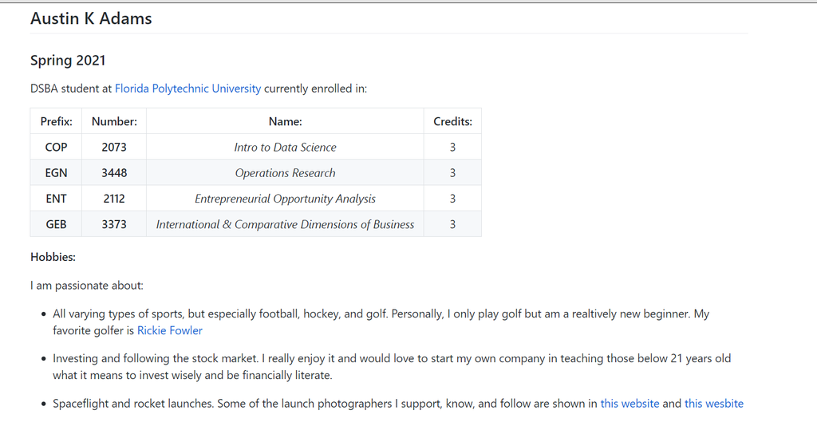

# Problem 2 (30 points)

*For this problem, you are asked to create a list of **3 concepts** you have learned about so far this semester, for at least 2 of the courses you are currently taking. Include the name of the course as a sub-heading (that is, using `##`), and the concepts as an unordered list. Include a link to information about at least one of the concept you listed (for example a link to the Wikipedia page about that concept/topics)*

## Intro to Operations Reasearch:

- [Break Even Analysis](https://www.investopedia.com/terms/b/breakevenanalysis.asp#:~:text=Break%2Deven%20analysis%20tells%20you,corporate%20budgeting%20for%20various%20projects.)
- Objective Functions with their relation to decision variables and constraints.
- Multiple Optimal Solutions, Infeasible Solutions, and Inifine Solutions

## Intro to Data Science:

- [Git Commands](https://confluence.atlassian.com/bitbucketserver/basic-git-commands-776639767.html) and how to operate Github.
- Basic R functions like paste, nchr, and seq, and how to install R packages.
- Varying data types and simple means on how to use them.

# Problem 3 (40 points)

In this problem you will practice some basic R operations. Include solutions to each items by inserting a new R chunk of code (make sure you run the chunk so that the output is displayed)

1. Create a variable called `my_name` that contains your preferred name.

```r
my_name <- "Austin Adams"
print(my_name)
```

```
## [1] "Austin Adams"
```

2. Create a variable called `name_length` that holds how many letters are in `my_name`.

```r
name_length <- nchar(my_name)
paste("The number of letters in the name,", my_name, "is", name_length)
```

```
## [1] "The number of letters in the name, Austin Adams is 12"
```

3. Show which value is bigger: $e^\pi$ or $\pi^e$.

```r
e <-  exp(1)
ifelse(e^pi > pi^e, "e^pi is bigger than pi^e", "pi^e is bigger than e^pi ") # this statement uses a test function, if yes, states it is bigger.
```

```
## [1] "e^pi is bigger than pi^e"
```

```r
# If it is not bigger, then it swaps the varaibles to indicate the other is bigger
```

4. Define a function called `add_tree` that takes a single argument and returns a value 3 times larger than the input.

```r
add_tree <- function(y)
  {
  return(y*3) # returns the arguement of y * 3 to make it 3X as large
  }
```

5. Use the colon operator `:` to create a vector `v` of numbers from 10 to 49. Find the length of this vector using the `length()` function.

```r
v <- 10:49
paste("The length of this vector is:", length(v))
```

```
## [1] "The length of this vector is: 40"
```

6. Use the `seq()` function to produce a range of number from -5 to 10 in 0.5 increments.

```r
seq(-5,10, by = 0.5)
```

```
##  [1] -5.0 -4.5 -4.0 -3.5 -3.0 -2.5 -2.0 -1.5 -1.0 -0.5  0.0  0.5  1.0  1.5  2.0
## [16]  2.5  3.0  3.5  4.0  4.5  5.0  5.5  6.0  6.5  7.0  7.5  8.0  8.5  9.0  9.5
## [31] 10.0
```